# Assignment_2

Jakub Rejdych

15 12 2022

## Ex 1

```r
density_obs <- c(5.5, 5.61, 4.88, 5.07, 5.26, 5.55, 5.36, 5.29, 5.58, 5.65, 5.57, 5.53, 5.62, 5.29, 5.44, 5.34, 5.79, 5.1, 5.27, 5.39, 5.42, 5.47, 5.63, 5.34, 5.46, 5.3, 5.75, 5.68, 5.85)

density_mean <- round(mean(density_obs), 3)
density_mean
```

```
## [1] 5.448
```

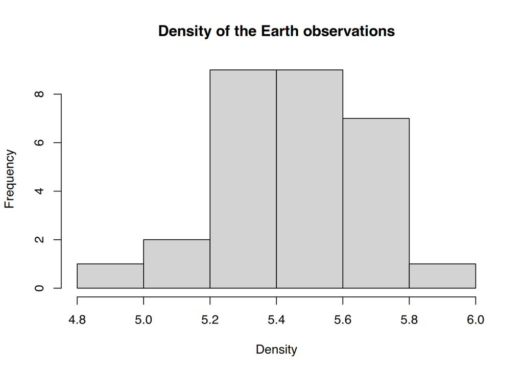

```r
hist(density_obs,
     main = "Density of the Earth observations",
     xlab = "Density")
```

3. We use t-test when we want to compare the means of two groups. For hypothesis testing it determines whether a process or treatment has an effect on the population of interest, or whether two groups are different from one another. In our case it is the second application of the t-test. We want to compare our single population of density values to a given average, so t-test fits this job perfectly.

```r
t.test(density_obs, mu = 5.1)
```

```
##
##  One Sample t-test
##
## data:  density_obs
## t = 8.4802, df = 28, p-value = 3.205e-09
## alternative hypothesis: true mean is not equal to 5.1
## 95 percent confidence interval:
##  5.363888 5.531974
## sample estimates:
## mean of x
##  5.447931
```

We take the alternative hypothesis $H_1:\mu\neq5.1$, because true mean isn’t equal to 5.1.

```r
t.test(density_obs, mu = 5.5, alternative = "less")
```

```
##
##  One Sample t-test
##
## data:  density_obs
## t = -1.2691, df = 28, p-value = 0.1074
## alternative hypothesis: true mean is less than 5.5
## 95 percent confidence interval:
##      -Inf 5.517726
## sample estimates:
## mean of x
##  5.447931
```

## Ex 2

```r
t.test(iris$Sepal.Width ~ iris$Species, subset = iris$Species %in% c("virginica", "versicolor"))
```

```
##
##  Welch Two Sample t-test
##
## data:  iris$Sepal.Width by iris$Species
## t = -3.2058, df = 97.927, p-value = 0.001819
## alternative hypothesis: true difference in means between group versicolor and group virginica is not equal to 0
## 95 percent confidence interval:
##  -0.33028364 -0.07771636
## sample estimates:
## mean in group versicolor  mean in group virginica
##                    2.770                    2.974
```

This test is used to test the hypothesis that two populations have equal means.  
In the result of the test on Virginica and Versicolor from Iris dataset, we get the result that means of this two groups are different.

## Ex 3

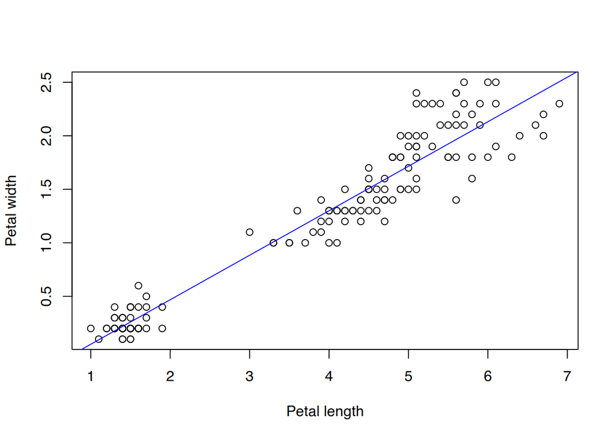

```r
model <- lm(iris$Petal.Width ~ iris$Petal.Length, data = iris)
plot(iris$Petal.Length, iris$Petal.Width, xlab = "Petal length", ylab = "Petal width")
abline(model, col = "blue")
```

```r
r_sq <- summary(model)$adj.r.squared
```

In our model $r^2 = 0.9266173$ and I think that it means that our model has really good quality, because it reveals than more than 92% of the variability observed in the target variable is explained by the regression

## Ex 4

```r
alpha <- 0.05
omnivores <- c(0.78, 0.80, 0.76, 0.78, 0.58, 0.64, 0.92, 0.86, 0.62, 0.54, 0.46)
vegetarians <- c(0.50, 0.32, 0.78, 0.68, 0.46, 0.32, 0.50, 0.68, 0.32, 0.86, 0.40, 0.36, 0.44, 0.62, 0.26)
m_omnivores <- qchisq(alpha / 2, length(omnivores) - 1)
M_omnivores <- qchisq(1 - alpha / 2, length(omnivores) - 1)
m_vegetarians <- qchisq(alpha / 2, length(vegetarians) - 1)
M_vegetarians <- qchisq(1 - alpha / 2, length(vegetarians) - 1)
m_omnivores
```

```
## [1] 3.246973
```

```r
M_omnivores
```

```
## [1] 20.48318
```

```r
m_vegetarians
```

```
## [1] 5.628726
```

```r
M_vegetarians
```

```
## [1] 26.11895
```

```r
omnivores_mean <- mean(omnivores)
vegetarians_mean <- mean(vegetarians)
vegetarians_var <- var(vegetarians)
omnivores_var <- 2 * omnivores_mean
omnivores_mean
```

```
## [1] 0.7036364
```

```r
vegetarians_mean
```

```
## [1] 0.5
```

```r
vegetarians_var
```

```
## [1] 0.03405714
```

```r
chisq.test(omnivores)
```

```
##
##  Chi-squared test for given probabilities
##
## data:  omnivores
## X-squared = 0.2954, df = 10, p-value = 1
```

```r
confidence_interval_var_omnivores_min <- ((length(omnivores) - 1) * omnivores_var ^ 2) / M_omnivores
confidence_interval_var_omnivores_max <- ((length(omnivores) - 1) * omnivores_var ^ 2) / m_omnivores
confidence_interval_std_omnivores_min <- sqrt(confidence_interval_var_omnivores_min)
confidence_interval_std_omnivores_max <- sqrt(confidence_interval_var_omnivores_max)
confidence_interval_var_vegetarians_min <- ((length(vegetarians) - 1) * vegetarians_var ^ 2) / M_vegetarians
confidence_interval_var_vegetarians_max <- ((length(vegetarians) - 1) * vegetarians_var ^ 2) / m_vegetarians
confidence_interval_std_vegetarians_min <- sqrt(confidence_interval_var_vegetarians_min)
confidence_interval_std_vegetarians_max <- sqrt(confidence_interval_var_vegetarians_max)
```